# The NOAA Fisheries Toolbox Survey

Christine Stawitz  
2/8/2018

### Who is the ST National Modeling Team?

- Patrick Lynch, head of ST NSAP program
- Corinne Bassin, Toolbox developer
- Christine Stawitz, Stock assessment modeler
- Matthew Supernaw, Software architect
- Rick Methot, Senior adviser

Goal: to support Stock Assessment efforts through developing assessment tools and increasing their usability and support via the NOAA Fisheries Toolbox.

### Survey goals

Gathering community input on investments of the National Modeling team on:

- Stock assessment models
- How the Fisheries Toolbox can best support users
- How the Fisheries Toolbox can support tool developers

### Responses

- 71 respondents across all centers

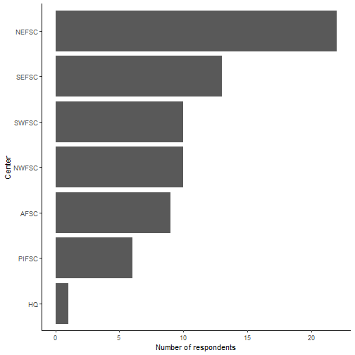

## Stock assessment models

### Stock Synthesis is most commonly used tool

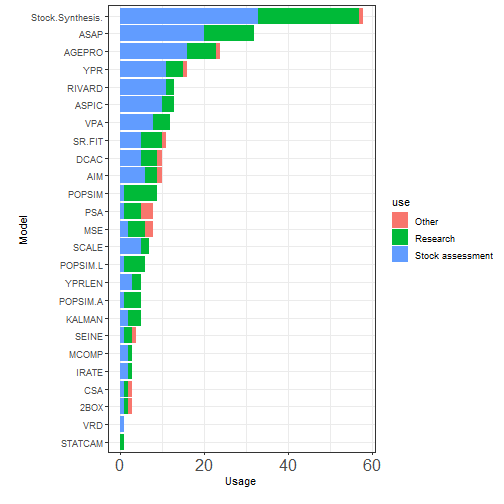

### Types of population models

- Ranked as needing feature improvements: Statistical catch-at-age models, statistical catch-at-length models, and multispecies assessment models
- Need maintenance only or can be deprecated: Virtual population analysis, delay-difference models, surplus production models

### How should the NMT invest in future modeling?

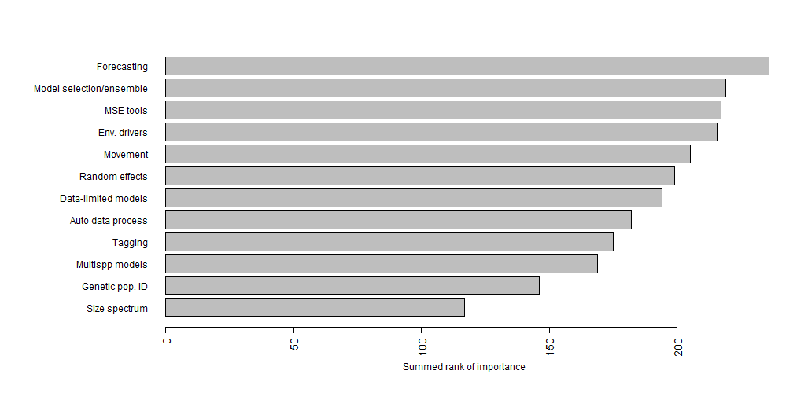

Improved forecasting techniques, ensemble approaches, MSE, and incorporating environmental drivers

## Tool use

### What UI do users prefer?

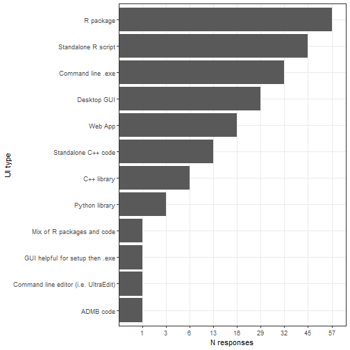

R is the most preferred platform. Command line and GUI are second.

### How are tools used?

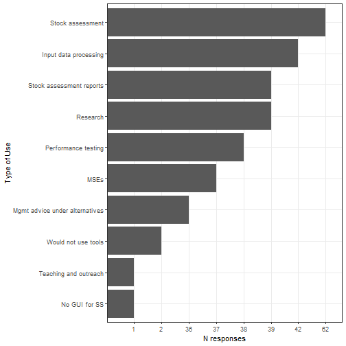

### What stops people from using tools?

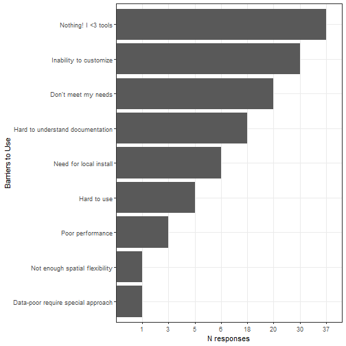

Most respondents like tools! But inability to customize and not meeting needs are close second.

## Supporting tool developers

### What type of support would most help tool developers?

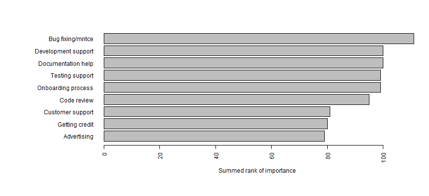

Tool developers need help with maintaining and fixing bugs, development, and creating documentation. Nearly all were highly ranked.

### Preferred ways to share tools

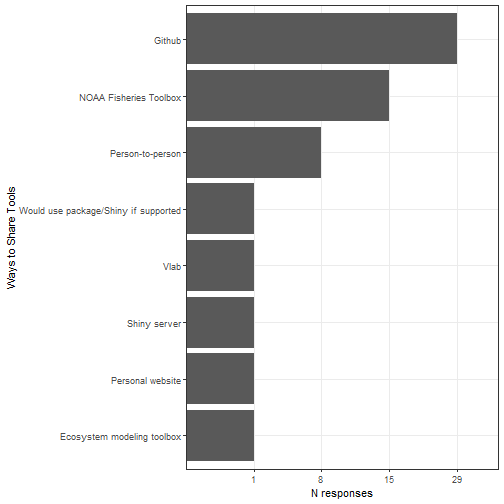